# TURKOGLU_Malik

2026-04-01

1. Introduction

On s’intéresse ici à un jeu de données qui concernent un groupe de poisson. Les variable sont les suivantes:

Id: identifiant du poisson

Viscera.weight: le poids des viscères du poisson

Diameter: le diamètre du poisson

Ici, on cherche à obtenir des modèles de régression linéaire qui permettent d’estimer la variable Viscera.weight à

partir de la variable Diameter dans un premier temps , puis à partir de la variable Dim3.

On cherche à estimer la variable Viscera.weight, le poids des viscères à partir de la variable Diameter ou à partir

de la variable Dim3.

```r
donnees <- read.csv( file = "TURKOGLU_MALIK.csv",
                     sep =","  ,
                     dec ="."  ,
                     stringsAsFactors = TRUE)
```

2. Estimation de Viscera.weight en fonction de Diameter

```r
resultat <- lm(formula = Viscera.weight~Diameter,
               data = donnees)
```

On met dans la variable resultat la variable qu’on veut expliquer et la variable explicative, ça nous permet

d’obtenir le calcul du modèle linéaire.

Maintenant, on trace le nuage de points qui montre l’évolution du poids des viscères selon le diamètre.

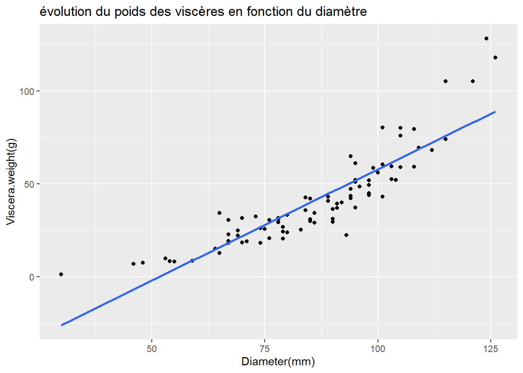

```r
ggplot(
  data = donnees,
  mapping = aes(x = Diameter, y = Viscera.weight)
  ) +
  geom_point() +
  geom_smooth(method = "lm", se = FALSE)+
  ggtitle("évolution du poids des viscères en fonction du diamètre")+
  xlab("Diameter(mm)")+
  ylab("Viscera.weight(g)")
```

La droite ne suit pas l’évolution du poids des viscères en fonction du diamètre. Il semble plus approprié ici de

tracer une courbe.

Pour tracer une courbe, on va utiliser la fonction FunctionModel.

On commence par créér deux nouvelles variables Viscera.weightLog et DiameterLog qui seront respectivement les

résultats de la fonction logarithmique appliquée aux variables Viscera.weight et Diameter.

```r
donnees$Viscera.weightLog <- log10(donnees$Viscera.weight)
```

```r
donnees$DiameterLog <- log10(donnees$Diameter)
```

On utilise encore ici la fonction lm pour calculer le modèle linéaire entre les variables logarithmiques.

```r
res <-lm(formula = Viscera.weightLog~DiameterLog,
               data = donnees)
```

On trace ensuite l’évolution du poids en fonction du diamètre avec les données à l’échelle logarithmique.

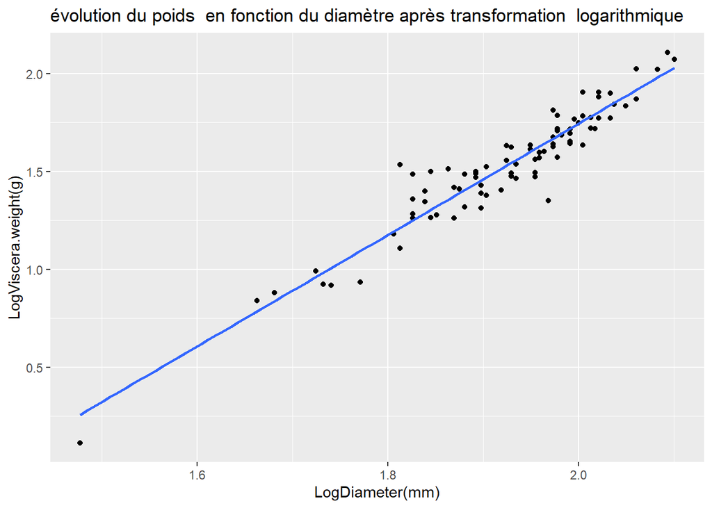

```r
ggplot(
  data = donnees,
  mapping = aes(x = DiameterLog, y = Viscera.weightLog)
  ) +
  geom_point() +
  geom_smooth( method = "lm", se = FALSE)+
  ggtitle("évolution du poids  en fonction du diamètre après transformation  logarithmique")+
  xlab("LogDiameter(mm)")+
  ylab("LogViscera.weight(g)")
```

On voit que les points sont autour de la droite, les variables semblent corrélées, on peut poursuivre l’étude du modèle.

Maintenant , on reprend les données d’origines et on trace un graphique à l’échelle logarithmique en appliquant les

coefficients du modèle linéaire de LogViscera.weight en fonction de LogDiameter.

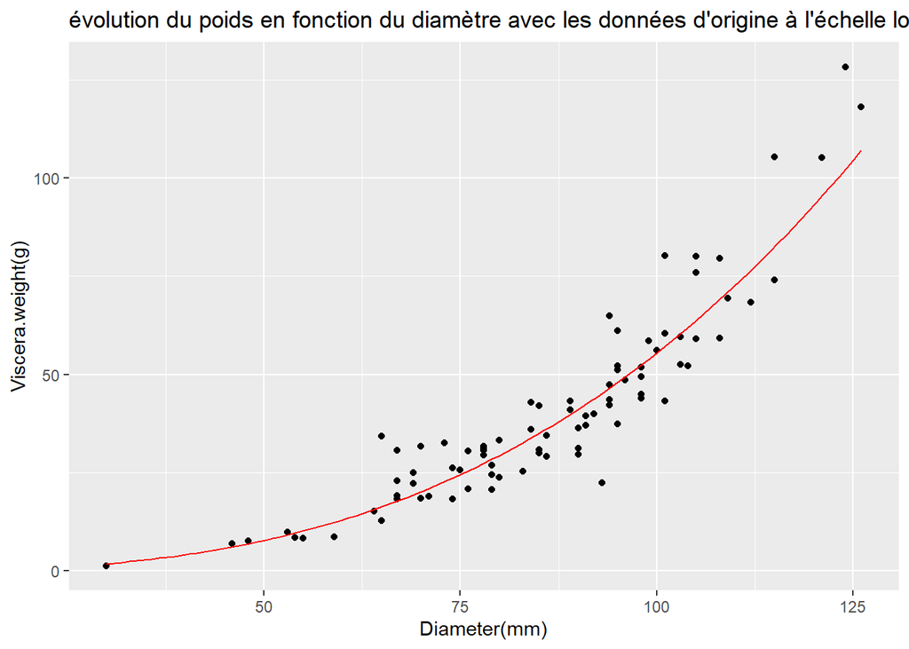

```r
functionModel <- function(x){10^res$coefficients[1]*x^res$coefficients[2]}
ggplot(
  data = donnees,
  mapping = aes(x = Diameter, y = Viscera.weight)
  ) +
  geom_point() +
  geom_function(fun = functionModel, colour = "red")+
  ggtitle("évolution du poids en fonction du diamètre avec les données d'origine à l'échelle logarithmique")+
  xlab("Diameter(mm)")+
  ylab("Viscera.weight(g)")
```

Ce modèle semble précis , les points sont autour de la courbe.

On peut poursuivre et calculer le modèle de régression.

```r
summary(res)
```

```
##
## Call:
## lm(formula = Viscera.weightLog ~ DiameterLog, data = donnees)
##
## Residuals:
##      Min       1Q   Median       3Q      Max
## -0.30420 -0.06171 -0.00544  0.05390  0.32328
##
## Coefficients:
##             Estimate Std. Error t value Pr(>|t|)
## (Intercept)  -3.9439     0.1938  -20.35   <2e-16 ***
## DiameterLog   2.8440     0.1007   28.25   <2e-16 ***
## ---
## Signif. codes:  0 '***' 0.001 '**' 0.01 '*' 0.05 '.' 0.1 ' ' 1
##
## Residual standard error: 0.09568 on 82 degrees of freedom
## Multiple R-squared:  0.9068, Adjusted R-squared:  0.9057
## F-statistic: 798.2 on 1 and 82 DF,  p-value: < 2.2e-16
```

3. Estimation de Viscera.weight à partir de Dim3

On étudie maintenant le lien entre Dim3 et Viscera.weight

On calcule le modèle de régresion linéaire de la variable Viscera.weight en fonction de la variable Dim3.

```r
resultat2 <- lm(formula = Viscera.weight~Dim3,
                data = donnees)
```

On trace le nuage de points qui montre l’évolution du poids des viscères en fonction de Dim3.

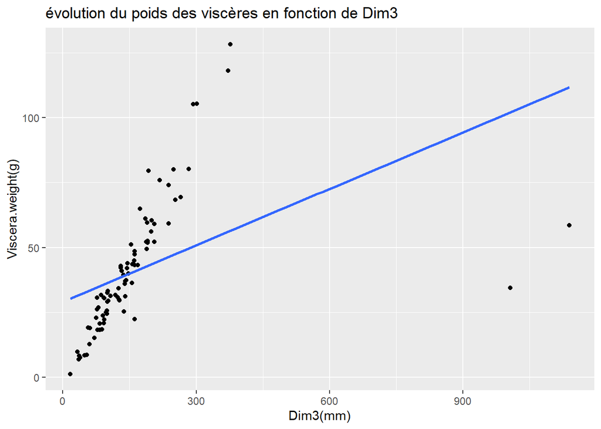

```r
ggplot(
  data = donnees,
  mapping = aes(x = Dim3, y = Viscera.weight)
  ) +
  geom_point() +
  geom_smooth(method = "lm", se = FALSE)+
  ggtitle("évolution du poids des viscères en fonction de Dim3")+
  xlab("Dim3(mm)")+
  ylab("Viscera.weight(g)")
```

Ici, on remarque une tendance , cependant la droite ne la suit pas , on peut essayer d’enlever les deux valeurs très

éloignées.

```r
 z <-subset(x = donnees, Dim3 < 930)
```

On utilise la fonction Subset pour supprimer les valeurs qui sont beaucoup plus grandes que les autres afin d’obtenir

une droite qui suit mieux la tendance des points.

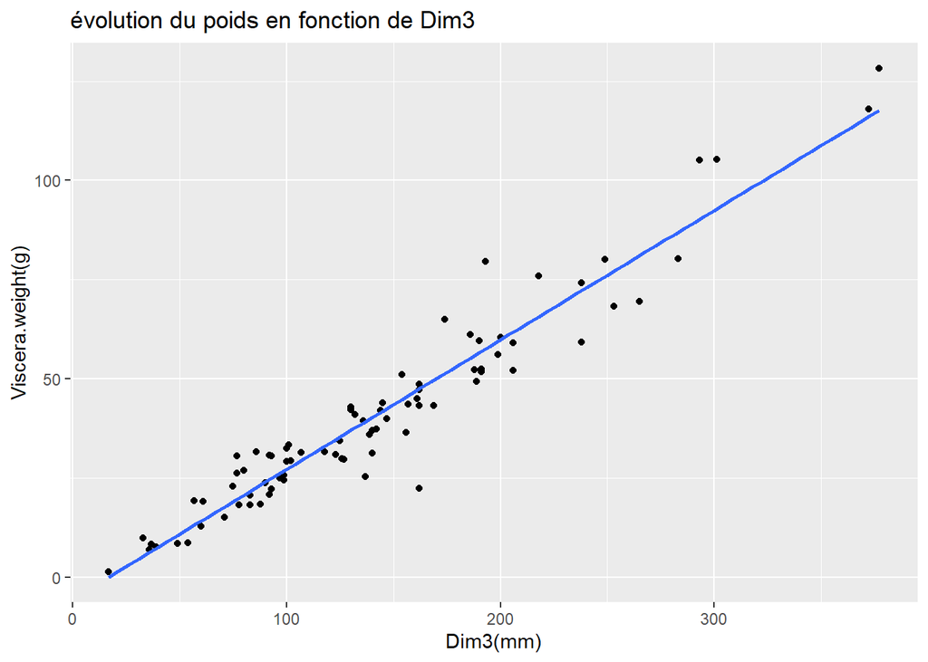

```r
ggplot(
  data = z,
  mapping = aes(x = Dim3, y = Viscera.weight)
  ) +
  geom_point() +
  geom_smooth(method = "lm", se = FALSE)+
  ggtitle("évolution du poids en fonction de Dim3")+
  xlab("Dim3(mm)")+
  ylab("Viscera.weight(g)")
```

Après avoir enlevé les valeurs atypiques, on obtient un graphique avec tous les points qui suivent l’allure de la

droite.

On calcule à nouveau le modèle de régression linéaire sans les données aberrantes.

```r
res2 <-lm(formula = Viscera.weight~Dim3,
          data = z)
```

On calcule à nouveau le modèle de régression linéaire sans les données aberrantes.

On affiche le résumé du calcul avec les nouvelles données.

```r
summary(res2)
```

```
##
## Call:
## lm(formula = Viscera.weight ~ Dim3, data = z)
##
## Residuals:
##     Min      1Q  Median      3Q     Max
## -25.001  -3.663  -0.545   4.479  21.971
##
## Coefficients:
##             Estimate Std. Error t value Pr(>|t|)
## (Intercept) -5.52871    1.68288  -3.285  0.00151 **
## Dim3         0.32672    0.01054  30.988  < 2e-16 ***
## ---
## Signif. codes:  0 '***' 0.001 '**' 0.01 '*' 0.05 '.' 0.1 ' ' 1
##
## Residual standard error: 6.985 on 80 degrees of freedom
## Multiple R-squared:  0.9231, Adjusted R-squared:  0.9221
## F-statistic: 960.2 on 1 and 80 DF,  p-value: < 2.2e-16
```

On a un R² de 0,9221 qui est supérieur à la p-value donc on peut poursuivre avec le modèle.

R² vaut 0.9221 ce qui signifie que 92,21% de la variance du poids qui est expliquée par Dim3.

On a Viscera.weight = Dim3*0,32672 -5,52

A chaque fois que Dim3 augmente de 1 le poids des viscères augmente de 0,32.

4. Conclusion

Viscera.weight = Dim3*0,32672 -5,52

On peut par conséquent en déduire qu’il est plus facile d’obtenir une idée précise du poids des viscères à partir de

Dim3, puisque le modèle avec Dim3 explique une plus grande partie de la variance de Viscera.weight.